# Artificial Surface Projections for 2050 | Norway

Magnus Merkle (SSB) and Kristine Grimsrud (SSB)

Naturregnskapsprosjekt, 16. December 2025

# Changelog

Changes since version 2:

- Added economic data (cross-sectional data for 2024 from SSB and projections to 2050 from NOREG) to improve artficial surface projections by municipality in steps 1 and 2.
- Added more data to improve suitability maps in step 3 and subsequently improve allocation of new artificial areas in step 4
- Added OSM street data to local maps for better visualisation of results
- Sorted encoding problems in final output data tables

# Abstract and Limitation

In this notebook we make artificial surface projections for Norway until 2050. The data inputs are:

- Land cover map (Grunnkart)
- Population projections (SSB)
- Municipality shapefiles
- Per capita tax revenues by municipality (SSB)
- Per capita GDP projections by fylke taken from NOREG simulations (NOREG)
- Municipality-level areas reserved for urban development (SSB)
- Flood risk maps (NVE)
- Slope maps (Copernicus)

The process is set up to run in four steps. First we estimate a function explaining artificial surface proportions by municipality, using cross-sectional data variation across municipalities. Second, we plug in data projections into the function from step 1, to compute the new artificial surface proportions for 2050. Third, we make a gridded map of urbanisation suitability. Fourth, we allocate new artificial surface cells to the land cover map for 2050, using the outputs of steps 2 and 3. To summarise: Absolute growth in artificial surface by municipality is the outcome of exogenously modelled results fed into an econometrically calibrated model, while allocation of new artificial surface within each municipality follows a separately defined land suitability logic.

# 1. Filepaths and packages

```r
# packages
library(dplyr)
library(tidyr)
library(terra)
library(ggplot2)
library(sf)
library(writexl)
library(readxl)
library(here)
library(viridisLite)
library(osmdata)
# filepath to the wd
wfp<-file.path(here::here())
# filepath to Grunnkart
gfp<-file.path("C:","Users","muk",
               paste0("OneDrive - Statistisk sentralbyr","\U00E5"),
               "data","INCA","Norway_files","Grunnkart")
# filepath to municipalities
mfp<-file.path("C:","Users","muk",
               paste0("OneDrive - Statistisk sentralbyr","\U00E5"),
               "data","Norway")
# filepath to population data
pfp<-file.path("C:","Users","muk",
               paste0("OneDrive - Statistisk sentralbyr","\U00E5"),
               "data","SSB","Population")
# filepath to economic data
efp<-file.path("C:","Users","muk",
               paste0("OneDrive - Statistisk sentralbyr","\U00E5"),
               "data","SSB","Kommune_econ")
# filepath to economic projection data
nfp<-file.path("C:","Users","muk",
               paste0("OneDrive - Statistisk sentralbyr","\U00E5"),
               "data","NOREG")
# filepath to arealreserver data
afp<-file.path("C:","Users","muk",
               paste0("OneDrive - Statistisk sentralbyr","\U00E5"),
               "data","Arealreserver_NO")
# filepath to slopedata
sfp<-file.path("C:","Users","muk",
               paste0("OneDrive - Statistisk sentralbyr","\U00E5"),
               "data","INCA","version_2_2","inca_input_floodcontrol",
               "DEM_and_Slope_maps")
# filepath to floodrisk data
ffp<-file.path("C:","Users","muk",
               paste0("OneDrive - Statistisk sentralbyr","\U00E5"),
               "data","INCA","Norway_files","NVE_flom","NVEKartdata","NVEData",
               "Flom_Aktsomhet")
```

# 2. Get data

In this section we run scripts to import data, aggregate it to the desired resolution, and match it in preparation for the subsequent analysis.

## 2.1 Land cover map

Grunnkart raster file.

```r
lcm <- terra::rast(file.path(gfp,"Grunnkart_OT.tif"))
```

## 2.2 Municipality map

Municipality shapefile.

```r
mm <- terra::vect(file.path(mfp,"Basisdata_0000_Norge_3035_Kommune_GeoJSON.geojson"))
mmd<-as.data.frame(mm)
```

## 2.3 Population tables

Population for 2024 and 2050, by municipality. Taken from SSB table 14288.

```r
pd <- read.csv(file.path(pfp,"14288_20251024-085215.csv"),sep=";")
colnames(pd)<-c("municipality","year","value")
pd <- pd %>% filter(year %in% c(2024,2050))
# seperate out identifier
pd <-pd %>% mutate(munid = substr(municipality, 1, 4))
```

## 2.4 Income tables

Taken from SSB table 12137. Tax from wealth and income per capita for 2024, by municipality (“Skatt på inntekt og formue inkludert naturressursskatt”). 5612 Guovdageaidnu - Kautokeino has no data. To fix this issue, we impose the mean of its neighbouring municipalities Karasjok and Alta.

```r
ed <- read_xlsx(file.path(efp,"12137_20251212-150026.xlsx"),sheet="Ark1")
colnames(ed)<-c("municipality","value")
ed$value <- as.numeric(ed$value)
ed$value[1]<-mean(ed$value[c(223,309)])
### seperate out munid
ed <-ed %>% mutate(munid = substr(municipality, 1, 4))
# remove svalbard (because we do not have it in Grunnkartet)
# and remove the "whole country" accounts
ed <- ed %>% filter(munid != "2111") # longyearbyen
ed <- ed %>% filter(munid != "EAK ") # hele landet
ed <- ed %>% filter(munid != "EAKU") # " uten oslo
ed <- ed %>% rename(taxrev_2024=value)
# open a concordance between fylke and kommune
concd <- read_xlsx(file.path(nfp,"kommune_fylke_conc.xlsx"),sheet="Ark1")
colnames(concd)<-c("fylke_n","fylke_c","kommune_n","kommune_c","kommune_cn")
# then the projection data (we first compute change in income per capita as a factor, then apply it to our tax revenue data)
fd <- read_xlsx(file.path(nfp,"BNP per cap 2024-2060 Referanse NOREG 2-3.xlsx"),sheet="REFB 2020",skip=2) %>% filter(t %in% c(2024,2050)) %>% select(- `% endring`) %>% pivot_wider(names_from = t,values_from= GDPR_per_cap) %>% mutate(econ_chg = 1 + (`2050` - `2024`) / `2024`) %>% select(-c(`2024`,`2050`)) %>% filter(region != "Norge")
# add unique identifier numbers (manually because R struggles with Norwegian letters...)
fd['fylke_id']<-NA
fd$fylke_id[1]<-3
fd$fylke_id[2]<-31
fd$fylke_id[3]<-32
fd$fylke_id[4]<-33
fd$fylke_id[5]<-34
fd$fylke_id[6]<-39
fd$fylke_id[7]<-40
fd$fylke_id[8]<-42
fd$fylke_id[9]<-11
fd$fylke_id[10]<-46
fd$fylke_id[11]<-15
fd$fylke_id[12]<-50
fd$fylke_id[13]<-18
fd$fylke_id[14]<-55
fd$fylke_id[15]<-56
fd <- fd %>% left_join(concd, by = join_by(fylke_id == fylke_c))
# then compute tax revenues for 2050 based on our GDP projection data
ad <- ed %>% left_join(fd,by=join_by(munid == kommune_c)) %>% mutate(taxrev_2050 = taxrev_2024*econ_chg) %>%
  select(municipality,taxrev_2024,munid,region,econ_chg,taxrev_2050)
# clean up
rm(concd,ed,fd)
```

## 2.5 Artificial surface density

Now we commpute the share of artificial surface in each municipality. First we need to define what artificial surface is. Below are all categories.

```r
unique(lcm)
```

```
##                                                                            Class
## 1                                           Bebyggelse/samferdsel (uspesifisert)
## 2                                                   Sammenhengende boligområder
## 3                Sammenhengende områder for tjenesteyting, handel \nog industri
## 4                                                         Oppdelte boligområder
## 5                                                                  Infrastruktur
## 6                                  Vei- og jernbanenettverk med tilhørende mark
## 7                                                                  Havneområder
## 8                                                                     Flyplasser
## 9                                                            Annen infrastruktur
## 10                                                     Mineralutvinningsområder
## 11                                                                        Parker
## 12                                                Sports- og rekreasjonsområder
## 13                                                      Gravlunder, kirkegårder
## 14                                                  Jordbruksmark (uspesifisert)
```

[output cut: 16 more lines]

For a start we just group all of the first thirteen categories of Grunnkartet together and call those artificial surface. We ignore variation within them. Then we compute total surface for each municipality and then artificial surface.

```r
# lcm with aggregated categories
lcma<-lcm
# basically a change of code
lcma[lcma %in% c(100,111,112,121,130,131,132,133,134,135,141,142,152)]<-199
values(lcma)<-as.numeric(values(lcma))
# now we need to mask grunnkartet to our municipalities
lcma <- mask(lcma,mm)
# Then count the number of cells of each kind in each polygon (municipality)
df <- terra::extract(lcma,mm,fun=table,method="simple")
# Then count all cells that could potentially be built up (classes 200,300,400,500)
df['artif']<-df$`199`
df['available']<-df$`199`+df$`200`+df$`320`+df$`400`+df$`410`+df$`420`+df$`440`+df$`520`
df['unavailable']<-df$`600`+df$`611`+df$`623`+df$`631`+df$`720`+df$`810`+df$`910`+df$`1100`+df$`1200`+df$`9900`
# keep only what is needed
df <- df %>% select(ID,artif,available,unavailable)
# add municipality names (same order)
df['munic']<-mmd$kommunenavn
df['munid']<-mmd$kommunenummer
df['artifshare']<-df$artif/df$available
```

## 2.5 Population density

Population density is the amount of population divided by available land.

```r
# match pd with df
unique(pd$munid) %in% df$munid
# join data
df <- df %>% left_join(pd %>% filter(year==2024) %>% select(-year) %>% rename(pop = value),by="munid")
# compute population density
df['popdens']<-df$pop/(0.01*df$available)
```

## 2.6 Add income

Join the data.

```r
unique(ad$munid) %in% df$munid
### add to df
df <- df %>% left_join(ad, by="munid")
```

# 3. Analysis Step 1

Let’s look at our data. Start with a plot of population density against artificial surface share.

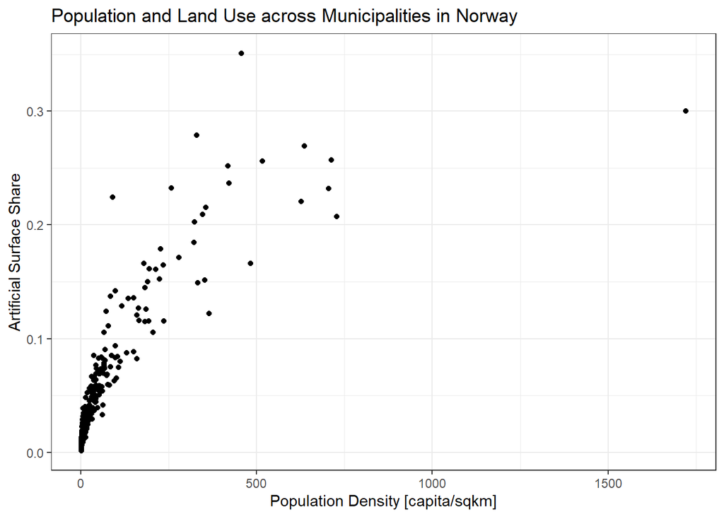

```r
# make a plot
ggplot(df,aes(x=popdens,y=artifshare)) +
  geom_point() +
  labs(title="Population and Land Use across Municipalities in Norway",
       y="Artificial Surface Share",x="Population Density [capita/sqkm]") +
  theme_bw()
```

This looks like a concave positive relationship as expected. Let’s define a function that could describe such a relationship. We want the the following properties:

- Start in the origin
- Be concave
- Level off at 1

A simple formulation to comply with these properties is:

$$f(x) = \frac{x}{x+a}$$

where parameter $a$ defines how quickly the function reaches 1. Now let’s use a non-linear weighted least squares estimation to get parameter $a$ based on our data. The weight we apply is the overall size of the municipality (larger size gives more weight).

```r
estresultp<-nls(artifshare ~ popdens/(popdens+a),data = df,weights=available+unavailable,start=list(a=1000))
summary(estresultp)
```

```
##
## Formula: artifshare ~ popdens/(popdens + a)
##
## Parameters:
##   Estimate Std. Error t value Pr(>|t|)
## a  1180.63      38.25   30.86   <2e-16 ***
## ---
## Signif. codes:  0 '***' 0.001 '**' 0.01 '*' 0.05 '.' 0.1 ' ' 1
##
## Residual standard error: 8.546 on 356 degrees of freedom
##
## Number of iterations to convergence: 6
## Achieved convergence tolerance: 1.421e-06
```

And then plot it.

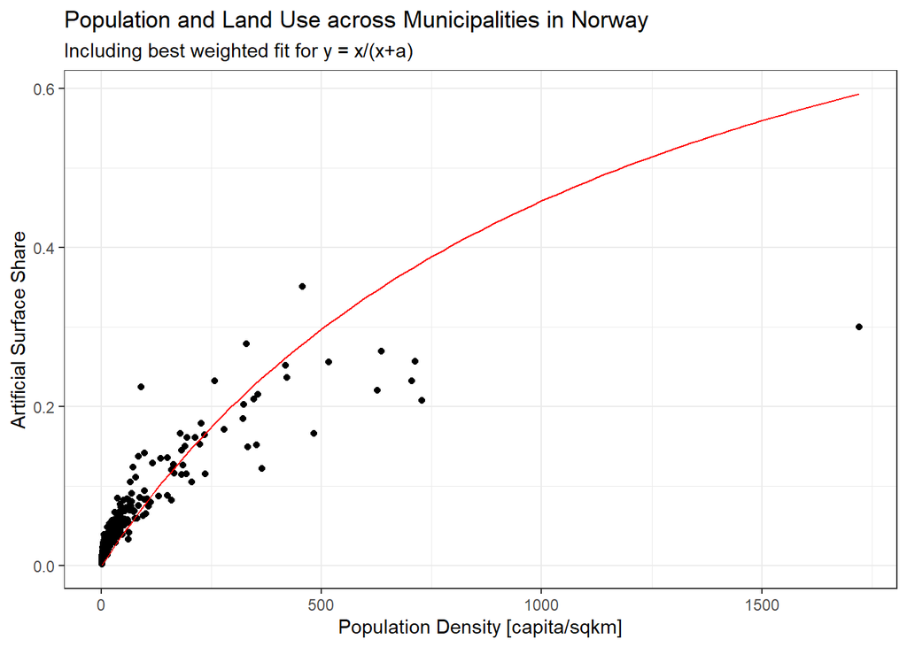

```r
# define the function for ggplot
a = coef(estresultp)
ourfunction<-function(x){x/(x+a)}
# make a plot
ggplot(df,aes(x=popdens,y=artifshare)) +
  geom_point() +
  labs(title="Population and Land Use across Municipalities in Norway",
       subtitle = paste0("Including best weighted fit for y = x/(x+a)"),
       y="Artificial Surface Share",x="Population Density [capita/sqkm]") +
  geom_function(fun=ourfunction,colour="red")+
  theme_bw()
```

```r
# clean up
rm(estresult)
```

This is what we would use if we only wanted population density as an explanatory variable. However, we have an additional explanatory variable to use, and that is income, approximated by tax revenue.

Now let’s plot tax revenue against artificial surface share.

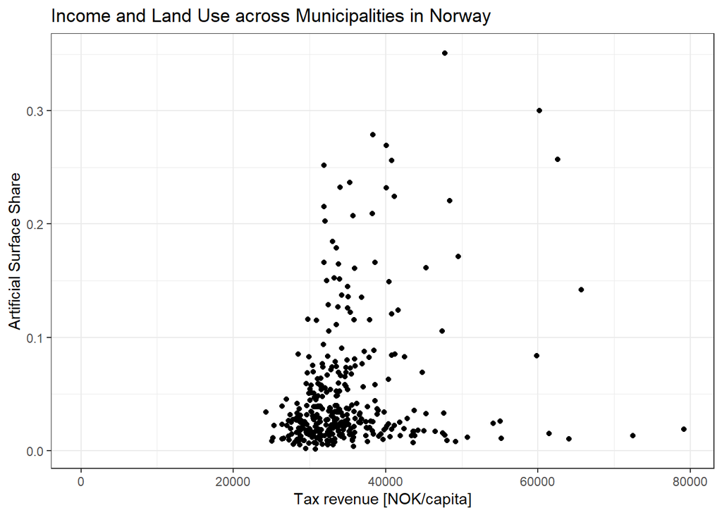

```r
# make a plot
ggplot(df,aes(x=taxrev_2024,y=artifshare)) +
  geom_point() +
  xlim(c(0,max(df$taxrev_2024))) +
  labs(title="Income and Land Use across Municipalities in Norway",
       y="Artificial Surface Share",x="Tax revenue [NOK/capita]") +
  theme_bw()
```

Here the functional form of the relationship is not as clean as in the case of population density, but that does not stop us from including it. We suggest a strictly positive relationship that is concave, so that increases in income at a lower level induce a larger marginal effect than increases in income at a higher level. Let’s look at what this function would look like, if tax revenue was the only predictor.

$$f(z) = \frac{z}{z+b}$$

Here again parameter $b$ defines how quickly the function reaches 1. Again we use a non-linear weighted least squares estimation to get parameter $b$ based on our data. The weight we apply is the overall size of the municipality (larger size gives more weight).

```r
estresulte<-nls(artifshare ~ taxrev_2024/(taxrev_2024+b),data = df,weights=available+unavailable,start=list(b=1000))
summary(estresulte)
```

```
##
## Formula: artifshare ~ taxrev_2024/(taxrev_2024 + b)
##
## Parameters:
##   Estimate Std. Error t value Pr(>|t|)
## b   992745      63593   15.61   <2e-16 ***
## ---
## Signif. codes:  0 '***' 0.001 '**' 0.01 '*' 0.05 '.' 0.1 ' ' 1
##
## Residual standard error: 14.54 on 356 degrees of freedom
##
## Number of iterations to convergence: 9
## Achieved convergence tolerance: 1.727e-07
```

And then plot it.

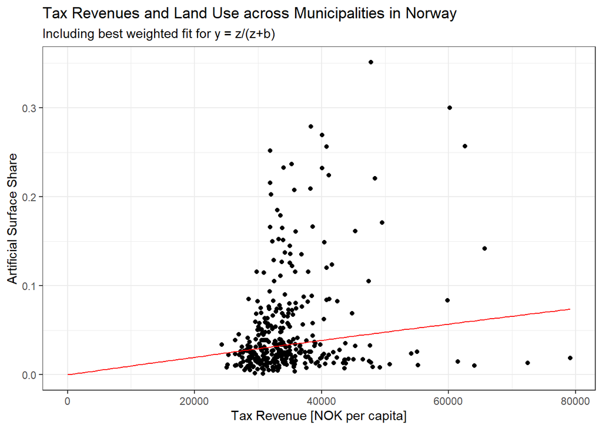

```r
# define the function for ggplot
b = coef(estresulte)
ourfunctione<-function(x){x/(x+b)}
# make a plot
ggplot(df,aes(x=taxrev_2024,y=artifshare)) +
  geom_point() +
  xlim(c(0,max(df$taxrev_2024)))+
  labs(title="Tax Revenues and Land Use across Municipalities in Norway",
       subtitle = paste0("Including best weighted fit for y = z/(z+b)"),
       y="Artificial Surface Share",x="Tax Revenue [NOK per capita]") +
  geom_function(fun=ourfunctione,colour="red")+
  theme_bw()
```

If we want to see how the function levels-off, we need to zoom out a bit. Let’s increase the horizontal axis limit to imagine the possibility of 10 times larger tax revenues than today:

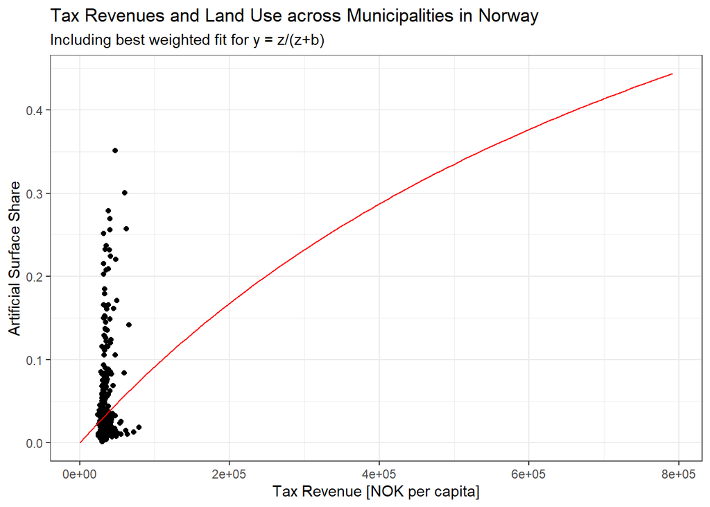

```r
# define the function for ggplot
b = coef(estresulte)
ourfunctione<-function(x){x/(x+b)}
# make a plot
ggplot(df,aes(x=taxrev_2024,y=artifshare)) +
  geom_point() +
  xlim(c(0,10*max(df$taxrev_2024)))+
  labs(title="Tax Revenues and Land Use across Municipalities in Norway",
       subtitle = paste0("Including best weighted fit for y = z/(z+b)"),
       y="Artificial Surface Share",x="Tax Revenue [NOK per capita]") +
  geom_function(fun=ourfunctione,colour="red")+
  theme_bw()
```

```r
# clean up
rm(estresulte)
```

Good. Now the challenge is that we want to have both predictors in one function. The desired properties are:

- Start in the origin when population density is zero (population without income is possible but not vice-versa)
- Be concave in both explanatory variables
- Level off at 1 in both explanatory variables

Here is one way of complying with these properties:

$$f(x,z) =
\frac{s[w*x+(1-w)*z*\frac{x}{x+a}]}{s[w*x+(1-w)*z*\frac{x}{x+a}]+1}$$

In this formulation $w$ gives us a weight for each predictor $w,z$ and parameter $s$ is a scaling parameter. We need to keep $\frac{x}{x+a}$ as a factor to $z$ so that we can ensure $f(x=0,z)=0$. Parameter $a$ defines how quickly the effect from $z$ turns on. So that $z$ has no effect when $x=0$, and it has full effect only when $x$ gets large. Note that our weight parameter $w$ is sensitive to the units used in each explanatory variable, so it cannot be interpreted as a pure share paramater (it could be interpreted as such if we first normalised our data, which we do not).

Ok so now let’s estimate this function making use of our cross-sectional data variation.

```r
estresulta<-nls(artifshare ~ (s*((w*popdens) + ((1-w)*taxrev_2024*(popdens/(popdens+a)))))/((s*((w*popdens) + ((1-w)*taxrev_2024*(popdens/(popdens+a))))+1)) ,data = df,weights=available+unavailable,start=list(a=0.1,w=0.5,s=0.01))
summary(estresulta)
```

```
##
## Formula: artifshare ~ (s * ((w * popdens) + ((1 - w) * taxrev_2024 * (popdens/(popdens +
##     a)))))/((s * ((w * popdens) + ((1 - w) * taxrev_2024 * (popdens/(popdens +
##     a)))) + 1))
##
## Parameters:
##    Estimate Std. Error t value Pr(>|t|)
## a 6.037e+01  1.060e+01   5.697 2.57e-08 ***
## w 9.882e-01  2.729e-03 362.173  < 2e-16 ***
## s 3.011e-04  3.521e-05   8.554 3.64e-16 ***
## ---
## Signif. codes:  0 '***' 0.001 '**' 0.01 '*' 0.05 '.' 0.1 ' ' 1
##
## Residual standard error: 5.477 on 354 degrees of freedom
##
## Number of iterations to convergence: 32
## Achieved convergence tolerance: 6.307e-06
```

And now we make a plot showing how our calibrated function performs. I have experimented a bit with three-dimensional plots, but found it did not look so tidy. So as an alternative, we make two-dimensional plots, and show the third dimension with fixed values for the second predictor.

So here the first version, where we show the association between population density and artificial surface share, fixing tax revenue. The thicker plotted line is the case where tax revenue is fixed at its median level across municipalities (33289 NOK/capita).

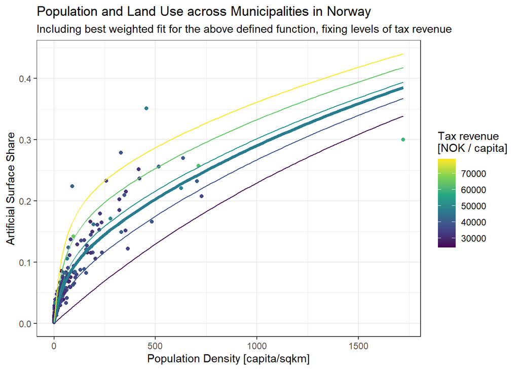

```r
# define the function for ggplot
a = coef(estresulta)[1]
w = coef(estresulta)[2]
s = coef(estresulta)[3]

# general version of our function
ourfunctiona<-function(x,z){
  y <- (s*((w*x) + ((1-w)*z*(x/(x+a)))))/((s*((w*x) + ((1-w)*z*(x/(x+a))))+1))
  return(y)
}
# ggplot can't deal with functions that have two variables, so we need to fix one.
ourfunctiona_1<-function(x){
  z<-1
  y <- (s*((w*x) + ((1-w)*z*(x/(x+a)))))/((s*((w*x) + ((1-w)*z*(x/(x+a))))+1))
  return(y)
}
ourfunctiona_2<-function(x){
  z<-20000
  y <- (s*((w*x) + ((1-w)*z*(x/(x+a)))))/((s*((w*x) + ((1-w)*z*(x/(x+a))))+1))
  return(y)
}
ourfunctiona_m<-function(x){
  z<-33289
  y <- (s*((w*x) + ((1-w)*z*(x/(x+a)))))/((s*((w*x) + ((1-w)*z*(x/(x+a))))+1))
  return(y)
}
ourfunctiona_3<-function(x){
  z<-40000
  y <- (s*((w*x) + ((1-w)*z*(x/(x+a)))))/((s*((w*x) + ((1-w)*z*(x/(x+a))))+1))
  return(y)
}
ourfunctiona_4<-function(x){
  z<-60000
  y <- (s*((w*x) + ((1-w)*z*(x/(x+a)))))/((s*((w*x) + ((1-w)*z*(x/(x+a))))+1))
  return(y)
}
ourfunctiona_5<-function(x){
  z<-80000
  y <- (s*((w*x) + ((1-w)*z*(x/(x+a)))))/((s*((w*x) + ((1-w)*z*(x/(x+a))))+1))
  return(y)
}


ggplot(df,aes(x=popdens,y=artifshare,col=taxrev_2024)) +
  geom_point() +
  scale_colour_viridis_c()+
  labs(title="Population and Land Use across Municipalities in Norway",
       subtitle = paste0("Including best weighted fit for the above defined function, fixing levels of tax revenue"),
       ,
       colour="Tax revenue \n[NOK / capita]",
       y="Artificial Surface Share",x="Population Density [capita/sqkm]") +
  geom_function(fun=ourfunctiona_1,colour=viridis(80000)[1])+
  geom_function(fun=ourfunctiona_2,colour=viridis(80000)[20000])+
  geom_function(fun=ourfunctiona_m,colour=viridis(80000)[33289],size=1.5)+
  geom_function(fun=ourfunctiona_3,colour= viridis(80000)[40000])+
  geom_function(fun=ourfunctiona_4,colour= viridis(80000)[60000])+
  geom_function(fun=ourfunctiona_5,colour= viridis(80000)[80000])+
  theme_bw()
```

And then a second version, where we show the association between tax revenue and artificial surface share, fixing population density. The thicker plotted line is the case where population density is fixed at its median level across municipalities (12 capita/sqkm).

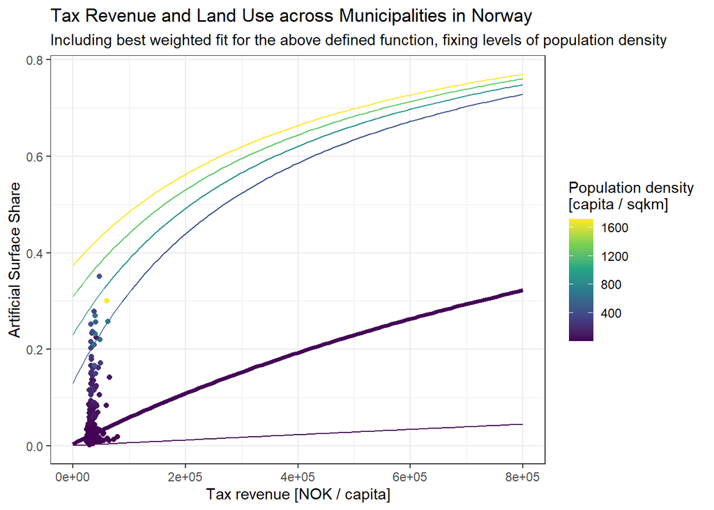

```r
## MM hier weiter

# ggplot can't deal with functions that have two variables, so we need to fix one.
ourfunctionat_1<-function(x){
  z<-1
  y <- (s*((w*z) + ((1-w)*x*(z/(z+a)))))/((s*((w*z) + ((1-w)*x*(z/(z+a))))+1))
  return(y)
}
ourfunctionat_m<-function(x){
  z<-12
  y <- (s*((w*z) + ((1-w)*x*(z/(z+a)))))/((s*((w*z) + ((1-w)*x*(z/(z+a))))+1))
  return(y)
}
ourfunctionat_2<-function(x){
  z<-500
  y <- (s*((w*z) + ((1-w)*x*(z/(z+a)))))/((s*((w*z) + ((1-w)*x*(z/(z+a))))+1))
  return(y)
}
ourfunctionat_3<-function(x){
  z<-1000
  y <- (s*((w*z) + ((1-w)*x*(z/(z+a)))))/((s*((w*z) + ((1-w)*x*(z/(z+a))))+1))
  return(y)
}
ourfunctionat_4<-function(x){
  z<-1500
  y <- (s*((w*z) + ((1-w)*x*(z/(z+a)))))/((s*((w*z) + ((1-w)*x*(z/(z+a))))+1))
  return(y)
}
ourfunctionat_5<-function(x){
  z<-2000
  y <- (s*((w*z) + ((1-w)*x*(z/(z+a)))))/((s*((w*z) + ((1-w)*x*(z/(z+a))))+1))
  return(y)
}


ggplot(df,aes(x=taxrev_2024,y=artifshare,col=popdens)) +
  geom_point() +
  scale_colour_viridis_c()+
  xlim(c(0,10*80000))+
  labs(title="Tax Revenue and Land Use across Municipalities in Norway",
       subtitle = paste0("Including best weighted fit for the above defined function, fixing levels of population density"),
       ,
       colour="Population density \n[capita / sqkm]",
       y="Artificial Surface Share",x="Tax revenue [NOK / capita]") +
  geom_function(fun=ourfunctionat_1,colour=viridis(2000)[1])+
  geom_function(fun=ourfunctionat_m,colour=viridis(2000)[12],size=1.5)+
  geom_function(fun=ourfunctionat_2,colour=viridis(2000)[500])+
  geom_function(fun=ourfunctionat_3,colour= viridis(2000)[1000])+
  geom_function(fun=ourfunctionat_4,colour= viridis(2000)[1500])+
  geom_function(fun=ourfunctionat_5,colour= viridis(2000)[2000])+
  theme_bw()
```

```r
# clean up
rm(estresulta,estresultp,b,ourfunction,ourfunctiona_1,ourfunctiona_2,ourfunctiona_3,ourfunctiona_4,ourfunctiona_5,ourfunctiona_m,ourfunctionat_1,ourfunctionat_2,ourfunctionat_3,ourfunctionat_4,ourfunctionat_5,ourfunctionat_m)
```

# 4. Analysis Step 2

Now we use population projections to compute the population density for 2050 in each municipality. Then we plug both population density projections and economic income projections into our calibrated function in order to compute new artificial surface share in 2050 for each municipality.

```r
# add projection to df
df <- df %>%
  left_join(pd %>% filter(year==2050) %>% select(-c(municipality,year)) %>% rename(pop_2050 = value),by="munid")
# compute new density
df['popdens_2050']<-df$pop_2050/(0.01*df$available)
# and compute the change
df['popdens_chg']<-df$popdens_2050-df$popdens
# and also relative change in percent
df['popdens_chg_rel']<-100*df$popdens_chg/df$popdens
# then compute the change we would expect using our function
df['artifshare_chg']<-ourfunctiona(x=df$popdens_2050,z=df$taxrev_2050) - ourfunctiona(x=df$popdens,z=df$taxrev_2024)
# then compute the new artificial surface share
df['artifshare_2050']<-df$artifshare + df$artifshare_chg
# and then compute the new artificial surface extent
df['artif_2050']<-round(df$artifshare_2050*df$available,digits=0)
# and compute the absolute change
df['artif_chg'] <- df$artif_2050 - df$artif
# clean up
rm(pd,ad)
```

Let’s make a plot showing artificial surface changes by municipality.

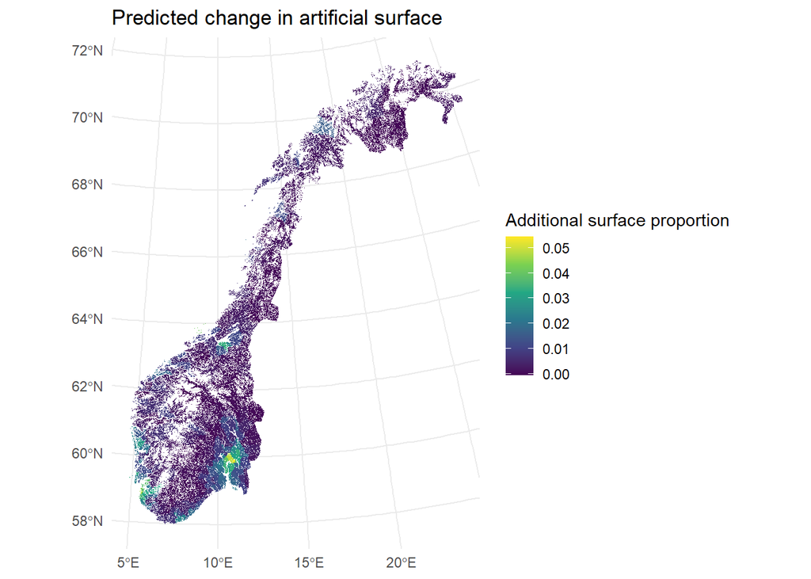

```r
# make a mask to show only available land
lcmb<-lcma
lcmb[lcmb %in% c(600,611,623,631,720,810,910,1100,1200,9900)]<-NA
lcmb[lcmb>1]<-1
mask_poly <- as.polygons(lcmb, dissolve = TRUE, na.rm = TRUE)
#  turn our data into a spatial vector object
dfd<-df %>% rename(kommunenummer = munid)
mdfd <- merge(mm,dfd,by="kommunenummer")
# mask it
mdfd <- crop(mdfd,mask_poly)
mdfd <- intersect(mdfd,mask_poly)
# nicer plots with sf objects in ggplot (ggplot doesn't read terra spatial vector objects)
mdfd_sf <- sf::st_as_sf(mdfd)
ggplot(mdfd_sf) +
  geom_sf(aes(fill = artifshare_chg),color=NA) +
  scale_fill_viridis_c() +
  theme_minimal() +
  labs(title = "Predicted change in artificial surface",
       fill = "Additional surface proportion")
```

```r
# clean up
rm(mdfd_sf,mdfd,df,mask_poly)
```

# 5. Analysis Step 3

Now we need to define the eligibility of each non-artificial cell to turn into an artificial cell. We implement a process that takes into account current municipal plans for urban development, density, flood risk, slope, land use, and distance.

Step i) We import municipality-plan data on areas that are reserved for development. These areas get a default suitability of 100, while all other areas are allocated a default suitability of 10. In the ensuing steps we take different kinds of information into account to reduce this default suitability defined in step i).

Step ii) We compute the proportion of artificial cells in a radius of 5 km. Then normalise the result to an indicator defined on [0;1]. This is an index of urbanisation potential based on given density of artificial surface around. We use it as a suitability reduction factor. Lower density reduces suitability more.

Step iv) We import slope data. Then compute the cumulative density function of slope that artificial surface is built on. This gives us the probability of artificial surface given a specific slope. We then we use the inverse of this cumulative density function to make another suitability reduction factor (steeper slope makes it the less likely to develop the area).

Step v) We now rank current (non-artificial) land use categories by urbanisation potential. This is a rather subjective exercise. Note category 310 (sown pastures and fields) does not exist in the current Grunnkart version, so we do not include it here. We define values in the following way. 320 Natural and seminatural grasslands get a value of 0.9. 520 Heathland and sub-alpine shrub get a value of 0.7. 400, 410, 420, 440 all kinds of forest get a value of 0.5. 200 Annual cropland gets a value of 0.3. So if a cell is annual cropland, its eligibility gets reduced by 70%. If it is grassland, then it only gets reduced by 10%. The rationale behind this ranking is that cropland and forest may on average have higher alternative use value (forestry and agriculture) than grassland and heathland.

Step vi) Next we compute the distance of each cell to its closest artificial cell. Then we normalise it to an indicator defined on [0;1] and subtract the result from 1, so that 0 is furthest away. So this is again an eligibility reduction factor, which reduces eligibility depending on how far the closest artificial cell is located.

Step vii) We define eligibility as the product of the results from steps i) to vi).

```r
## Step i) Arealreserver
# a) Import, reproject, rasterize
brv <- terra::vect(file.path(afp,"G6_ArealreserveBolig_2025.shp"))
nrv <- terra::vect(file.path(afp,"G6_ArealreserveNaring_2025.shp"))
frv <- terra::vect(file.path(afp,"fritidsbygg_2024.shp"))
brv<-terra::project(brv,lcm)
nrv<-terra::project(nrv,lcm)
frv<-terra::project(frv,lcm)
brr<-terra::rasterize(brv,lcm)
nrr<-terra::rasterize(nrv,lcm)
frr<-terra::rasterize(frv,lcm)
# b) Aggregate
brr[is.na(brr)]<-0
nrr[is.na(nrr)]<-0
frr[is.na(frr)]<-0
arr<-brr+frr+nrr
# right some areas overlap, and that's because we use reserve areas from different years.
# anyway, we just treat everything as 1.
arr[arr==2]<-1
# c) mask and impose suitability 100 for reserve areas, 10 for all other.
s1r <- mask(arr,lcma)
s1r[s1r==1]<-100
s1r[s1r==0]<-10
# d) clean up
rm(brv,nrv,frv,brr,nrr,frr,arr)
gc()

## Step ii) Density
# a) Make a target map. 1 is artificial, 0 is everything else.
targetr <- lcma
targetr[targetr==199]<-1
targetr[targetr>1]<-0
# b) Make it coarser from 1ha to 4ha (because MM's laptop can't handle the focal function otherwise)
targetrc <- terra::aggregate(targetr,fact=2,fun=mean)
# c) Make a round moving window of 5km radius
w = terra::focalMat(targetrc,5000,type = "circle")
w[w>0]<-1 # all artificial cells get the same weight of 1
# d) run the focal function to compute the sum of artificial cells within 5km radius for each cell
r_sum <- terra::focal(targetrc,w,fun=sum,na.policy = "omit")
# e) Disaggregate again using interpolation
r_fine <- terra::disagg(r_sum,fact=2,method="bilinear")
# f) Then we need to align extents using interpolation
r_fine_a <- terra::resample(r_fine,lcma,method="bilinear")
# g) normalise and make an index, gives us the result
s2r <- r_fine_a/max(values(r_fine_a),na.rm=T)
# h) clean up
rm(targetr,targetrc,w,r_sum,r_fine,r_fine_a)
gc()

## Step iii) Flood risk
# a) Import
flood <- terra::rast(file.path(ffp,"Flom_AktsomhetOmr_form.tif"))
# b) Find out proportion of current artificial areas in flood risk areas
df<-as.data.frame(cbind(values(lcma),values(flood)))
colnames(df)<-c("cover","flood")
df<-df %>% filter(cover==199)
gc()
fprop<-(df %>% filter(flood==1) %>% nrow())/nrow(df)
# b) Allocate adjustment values and save
flood[flood==1]<-fprop
flood[is.na(flood)]<-1
s3r <- flood
# c) clean up
rm(flood,df,fprop)

## Step iv) Slope
# a) Import and align
slop <- terra::rast(file.path(sfp,"dt1_slope_INCA_EPSG3035_100m_Byte.tif"))
slop<-crop(slop,lcm)
slop<-mask(slop,lcm)
slop <- resample(slop, lcm, method = "bilinear")
slop[is.na(slop)]<-0
# b) FInd out slope of current artificial areas
df<-as.data.frame(cbind(values(lcma),values(slop)))
colnames(df)<-c("cover","slope")
df<-df %>% filter(cover==199)
gc()
# c) Create suitability reduction based on CDF of current slope
s4rfun<-ecdf(df$slope)
s4r<-1-terra::app(slop, fun = s4rfun) # inverse of cdf
# d) clean up
rm(slop,df,s4rfun)

## Step v) Current land cover
# a) Baseline is lcm
s5r<-lcma
# b) unavailable
s5r[s5r %in% c(600,611,623,631,720,810,910,1100,1200,9900)]<-0
# c) unavailable because already artificial
s5r[s5r %in% c(199)]<-0
# d) best
s5r[s5r == 320]<-0.9
# e) second best
s5r[s5r == 520]<-0.7
# f) third best
s5r[s5r %in% c(400,410,420,440)]<-0.5
# g) fourth best
s5r[s5r == 200]<-0.3

## Step vi) Distance
# a) Make a target map, 1 is artificial, all else is NA
targetr <- lcma
targetr[targetr==199]<-1
targetr[targetr>1]<-NA
# b) Compute distance of each cell to the target
distm <- terra::distance(targetr)
distm<-terra::mask(distm,lcmb)
# c) Then our adjustment map
s6r <- 1-distm/max(values(distm),na.rm=T)
s6ra<-s6r # one version for the s6r plot
s6r[is.na(s6r)]<-1 # override the masking from lcmb, just so we can get a continuous map. We'll mask out lcmb later.
# d) Clean up
rm(distm,targetr)

## Step vii) Create our final eligibility map as a product of all
elig_r_1 <- s1r
elig_r_2 <- s1r*s2r
elig_r_3 <- s1r*s2r*s3r
elig_r_4 <- s1r*s2r*s3r*s4r
elig_r_5 <- s1r*s2r*s3r*s4r*s5r
elig_r_6 <- s1r*s2r*s3r*s4r*s5r*s6r
s_r<-c(s1r,s2r,s3r,s4r,s5r,s6ra)
names(s_r)<-c("i) Default suitability","ii) Density reduction factor",
                 "iii) Flood risk reduction factor",
                 "iv) Slope reduction factor",
                 "v) Land cover reduction factor",
                 "vi) Distance reduction factor")
## Prepare case area plots
oslo_ext <- ext(4300000, 4400000, 4020000, 4120000)
hallingdal_ext <- ext(4200000, 4350000, 4100000, 4250000)
lofoten_ext <- ext(4400000, 4650000, 4900000, 5150000)
finnmark_ext <- ext(4750000, 5200000, 5050000, 5500000)
```

Now let’s look closer at some case areas, to better see what we do here. For easier orientation we add Open Street Map data to the plots.

```r
# OSM data
# A function to download roads data for specific shapes within Norway
osm_get_streets<-function(kext,lcm){
  # crop and reproject lcm
  k_lcm<-crop(lcm,kext,mask=T)
  k_lcm_w84 <- project(k_lcm, "EPSG:4326")
  # download roads
  roads <- k_lcm_w84 %>%
    sf::st_bbox() %>%
    osmdata::opq() %>%
    osmdata::add_osm_feature(key="highway",value = c("motorway","trunk","primary")) %>%
    osmdata_sf()
  # reproject
  roads_t <- roads$osm_lines %>%
    terra::vect() %>%
    terra::project(lcm)
  # return result
  return(roads_t)
}
# then run
oslo_r<-osm_get_streets(oslo_ext,lcm)
gc()
hallingdal_r<-osm_get_streets(hallingdal_ext,lcm)
gc()
lofoten_r<-osm_get_streets(lofoten_ext,lcm)
gc()
finnmark_r<-osm_get_streets(finnmark_ext,lcm)
gc()
```

Here an example of the steps for the Oslo area.

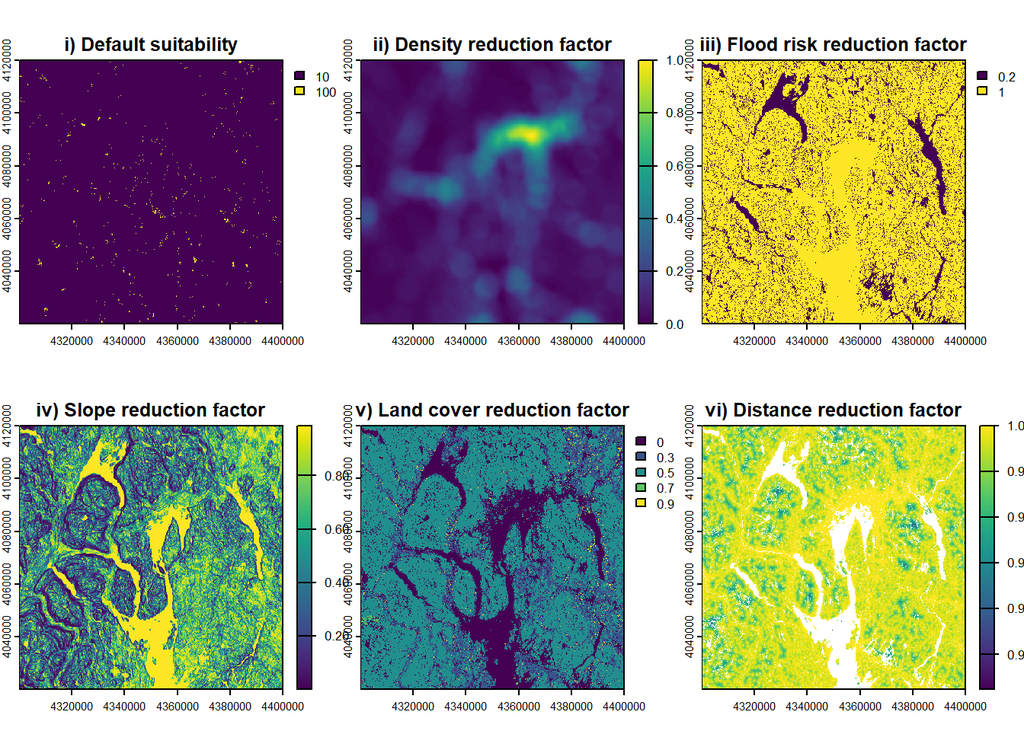

```r
print("Oslo")
plot(s_r,ext=oslo_ext)
```

And for Hallingdal

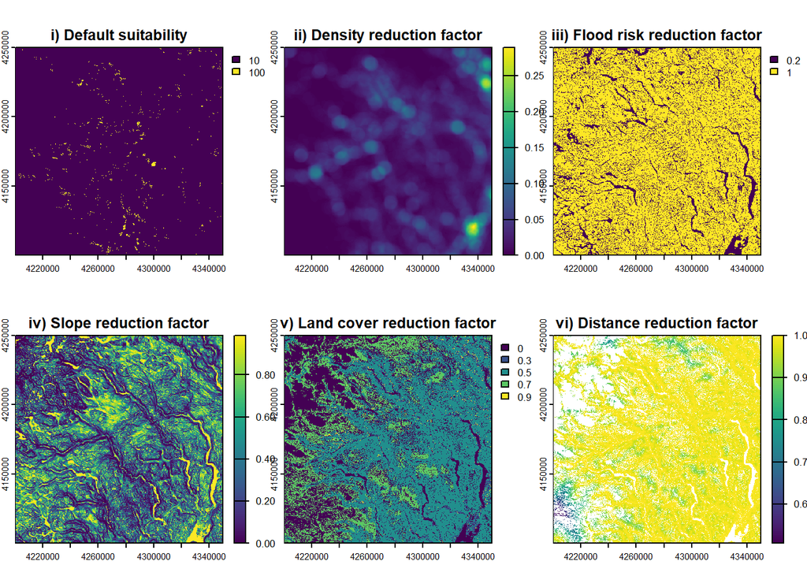

```r
print("Hallingdal")
plot(s_r,ext=hallingdal_ext)
```

And for Lofoten

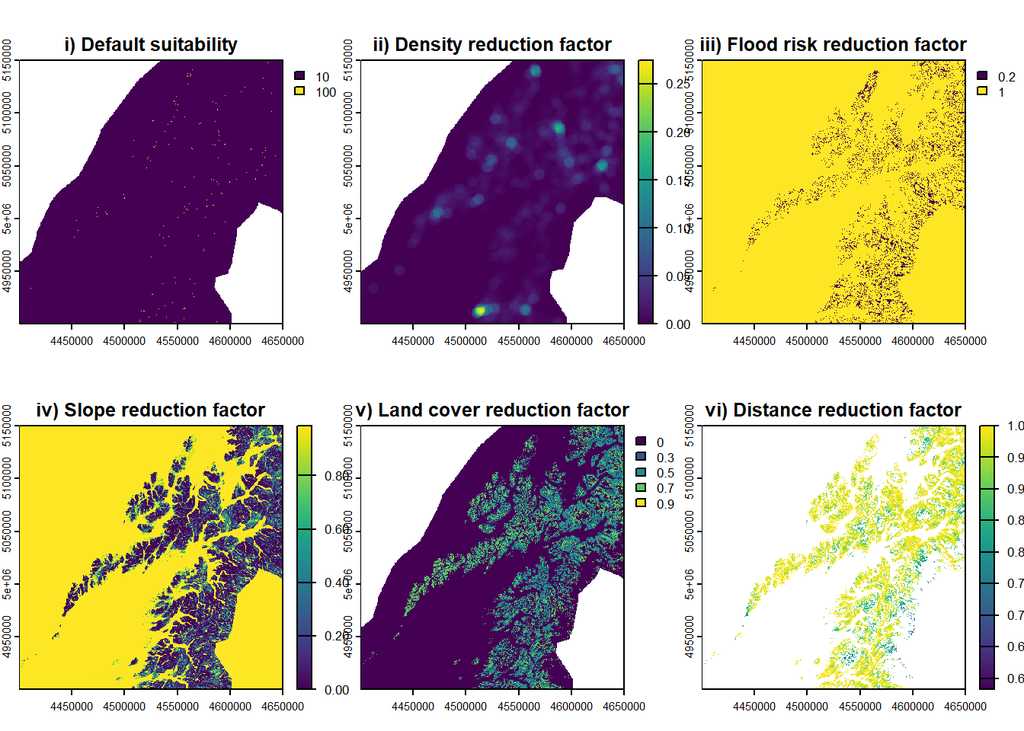

```r
print("Lofoten")
plot(s_r,ext=lofoten_ext)
```

And for Finnmark

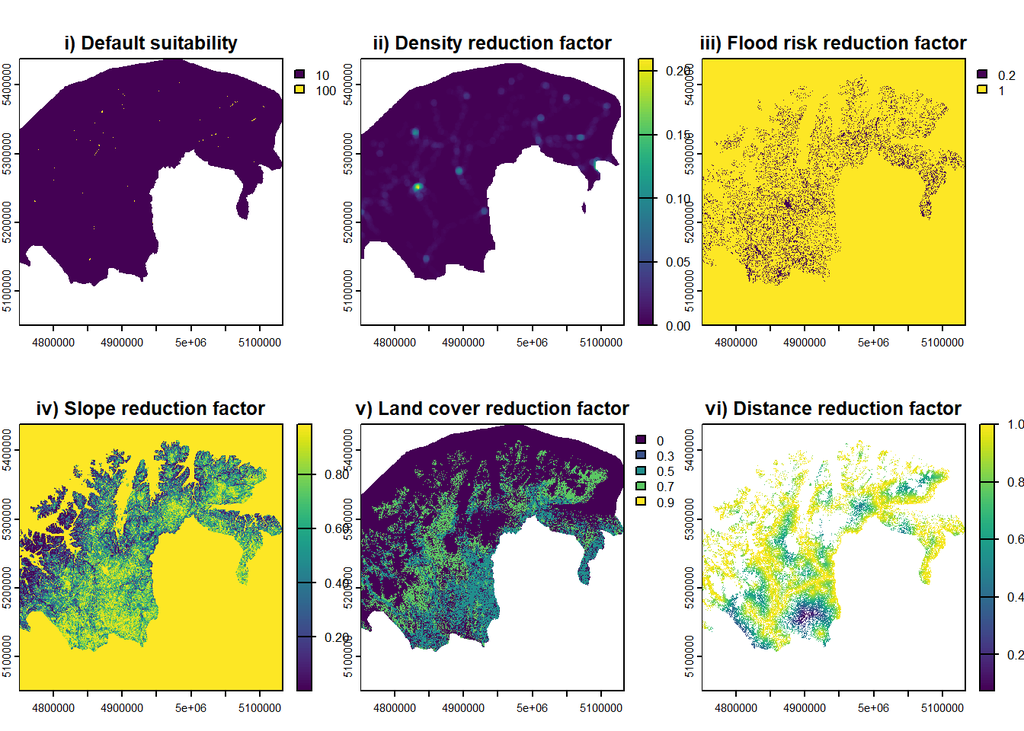

```r
print("Finnmark")
plot(s_r,ext=finnmark_ext)
```

```r
gc()
rm(s1r,s2r,s3r,s4r,s5r,s6ra)
```

Then let’s have a look at our resulting map of eligibility. Note that after multiplying default suitability with our six suitabaility reduction factors, most cells have a substantially lower suitability value than in the unadjusted case. This has no consequence for the absolute number of new allocated artificial surface in step 4, because in our model only relative suitability matters within each municipality.

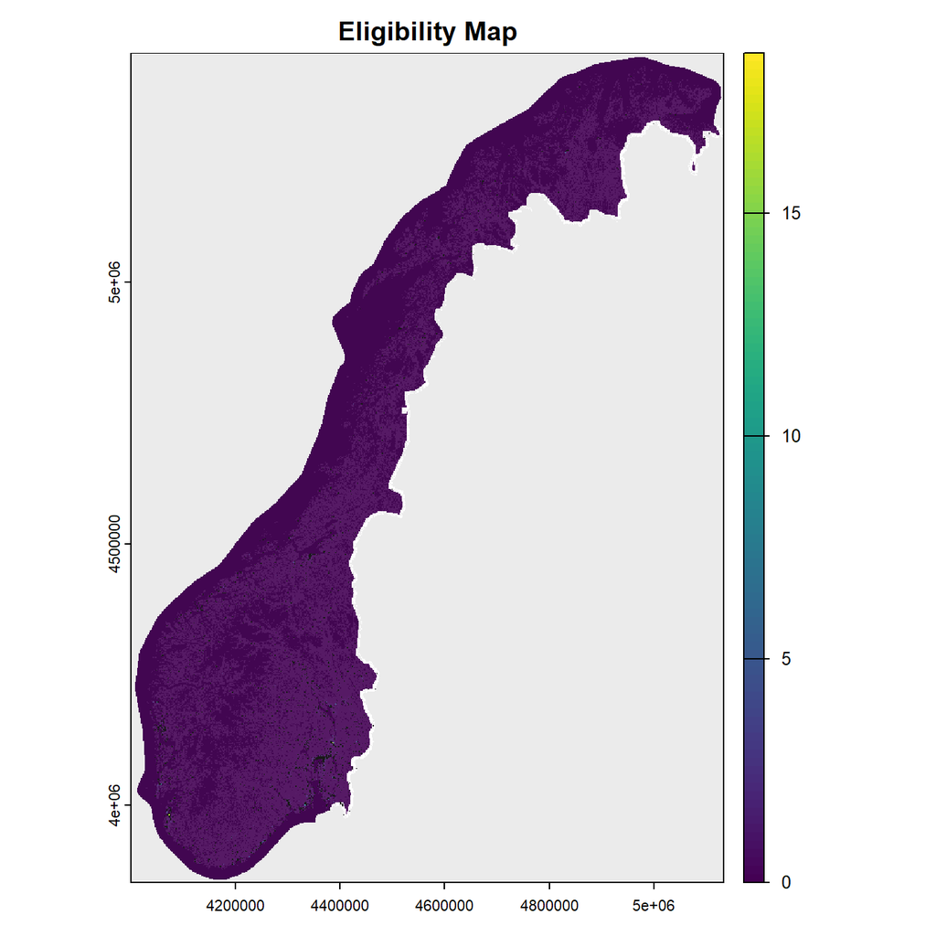

```r
# Here is our raster
plot(elig_r_6,main="Eligibility Map")
# Make a layer with already urban cells
urb<-lcma
urb[urb==199]<-1
urb[urb>1]<-NA
# And add that
plot(urb,col="black", add=T,legend=F)
plot(lcmb,colNA="grey20",col="white",add=T,alpha=0.1,legend=F)
```

Let’s zoom in on a few smaller areas to see a bit more. So here is the plot for Oslo area.

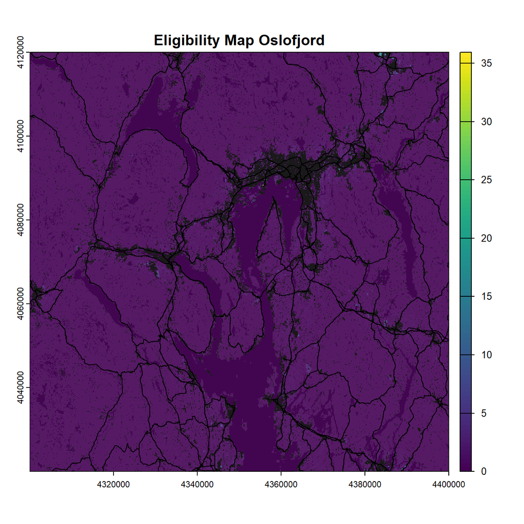

```r
plot(crop(elig_r_6,oslo_ext),main="Eligibility Map Oslofjord")
plot(crop(urb,oslo_ext),col="black", add=T,legend=F)
plot(crop(lcmb,oslo_ext),colNA="grey20",col="white",add=T,alpha=0.1,legend=F)
plot(crop(oslo_r,oslo_ext),add=T)
```

And let’s zoom in on the Hallingdal area.

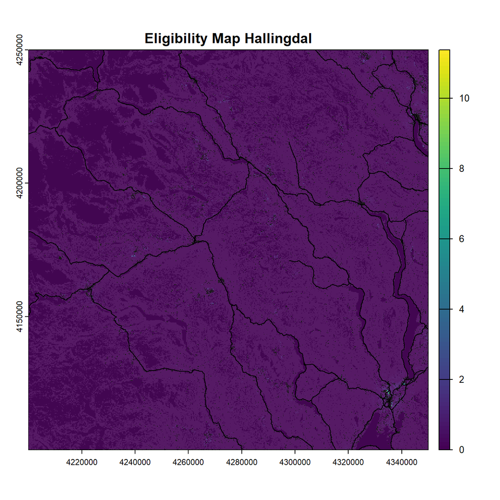

```r
plot(crop(elig_r_6,hallingdal_ext),main="Eligibility Map Hallingdal")
plot(crop(urb,hallingdal_ext),col="black", add=T,legend=F)
plot(crop(lcmb,hallingdal_ext),colNA="grey20",col="white",add=T,alpha=0.1,legend=F)
plot(crop(hallingdal_r,hallingdal_ext),add=T)
```

And on the Lofoten area.

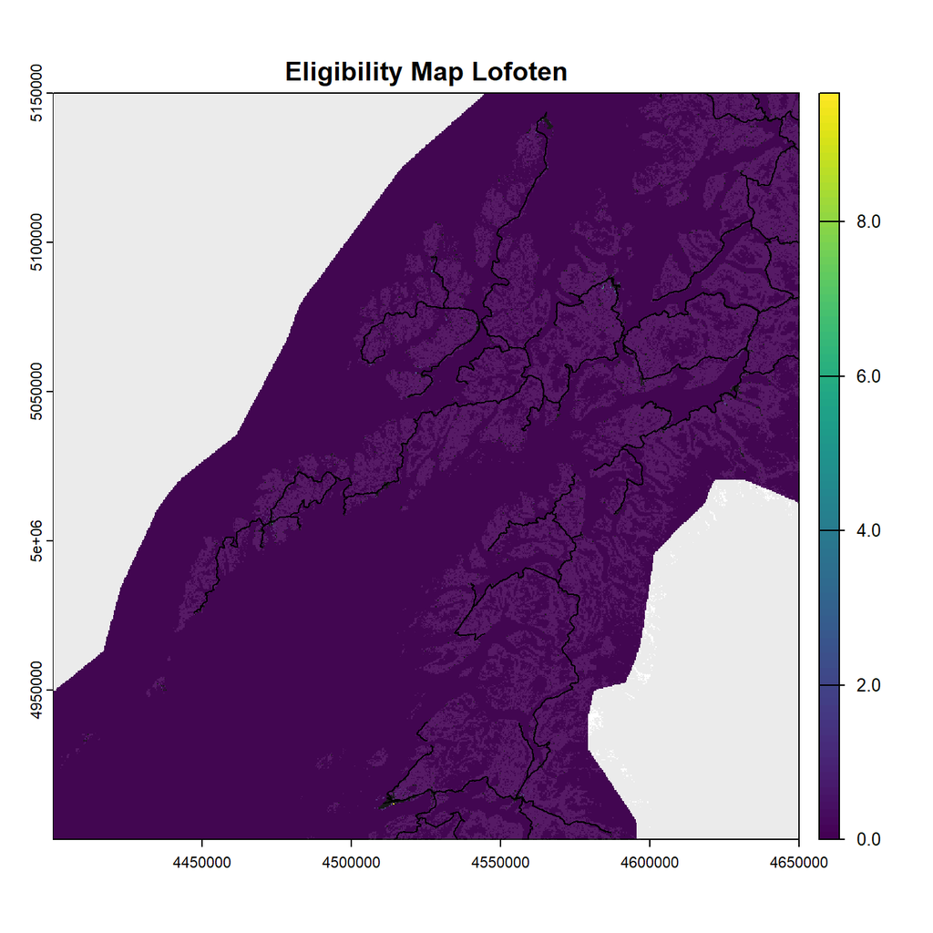

```r
plot(crop(elig_r_6,lofoten_ext),main="Eligibility Map Lofoten")
plot(crop(urb,lofoten_ext),col="black", add=T,legend=F)
plot(crop(lcmb,lofoten_ext),colNA="grey20",col="white",add=T,alpha=0.1,legend=F)
plot(crop(lofoten_r,lofoten_ext),add=T)
```

And finally on Finnmark.

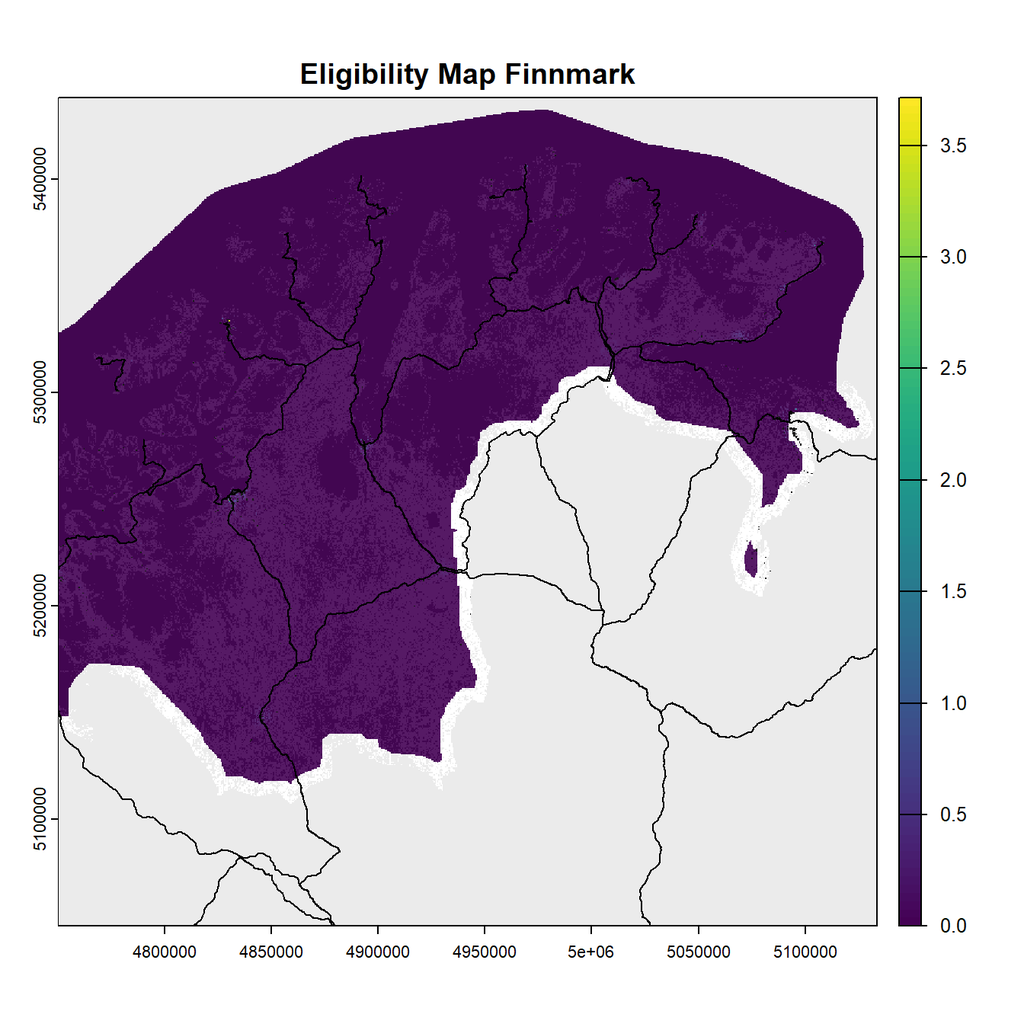

```r
plot(crop(elig_r_6,finnmark_ext),main="Eligibility Map Finnmark")
plot(crop(urb,finnmark_ext),col="black", add=T,legend=F)
plot(crop(lcmb,finnmark_ext),colNA="grey20",col="white",add=T,alpha=0.1,legend=F)
plot(crop(finnmark_r,finnmark_ext),add=T)
```

# 6. Analysis Step 4

Now as the last step of our analysis we allocate new artificial cells to the land cover map. We do this on the basis of eligibility, defined by step 3. The number of cells to be added in each municipality comes from step 2. We implement the process as a loop across municipalities.

```r
gc()
# first mask our eligibility map with lcmb
elig_rf<-mask(elig_r_6,lcmb)
# first define negative artificial surface change as zero change.
dfd$artif_chg[dfd$artif_chg<0]<-0
# we need character municipality identification codes (otherwise rasterize will return levels)
mmc<-mm
mmc$kommunenummer <- as.character(mmc$kommunenummer)
# Extract eligibility values for each municipality
elig_df <- terra::extract(elig_rf, mmc)
colnames(elig_df)<-c("ID","elig")
# and then i also want kommunenummer
elig_df$kommunenummer <- mmc$kommunenummer[elig_df$ID]
# now compute the thresholds in a loop across municipalities
dfd['elig_tld']<-NA
dfd['dupl_elig_warn']<-NA
for(i in 1:nrow(dfd)){
  if(dfd$artif_chg[i]>0){
    # for debugging
    # print(dfd$munic[i])
    # operation
    tmpv <- sort(elig_df$elig[elig_df$kommunenummer==dfd$kommunenummer[i]],decreasing = T)
    hdupl <- tmpv[duplicated(tmpv)][1] # find the highest duplicated eligibility value
    dfd$elig_tld[i] <- tmpv[dfd$artif_chg[i]]
    dfd$dupl_elig_warn <- if(hdupl < dfd$elig_tld[i]){"Ok"} else {"Warning! Duplicates!"}
    rm(tmpv,hdupl)
  }
}
# now set the threholds for those municipalities where there is no urbanisation to 100
dfd$elig_tld[is.na(dfd$elig_tld)]<-100
# now merge with our municipality spatial vector
mdfd <- merge(mm,dfd,by="kommunenummer")
# then rasterize
eligtld_r<-terra::rasterize(mdfd,lcma,field="elig_tld")
# good and now the raster of new artificial cells
newart_r<-lcma
newart_r[newart_r>0]<-NA
# new cells where eligibilty is at least as large as the minimum threhold
newart_r[elig_rf>=eligtld_r]<-1
```

Here a plot of the result. A bit difficult to see when looking at the whole country.

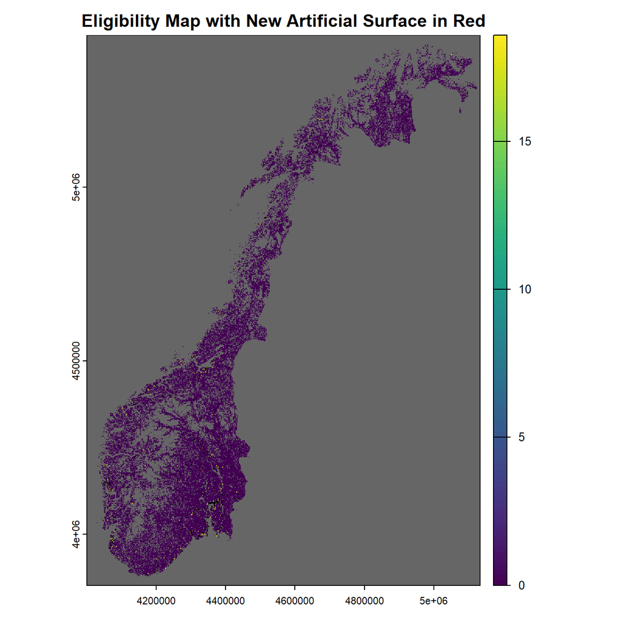

```r
# Here is our raster
plot(elig_rf,colNA="grey40",main="Eligibility Map with New Artificial Surface in Red")
# And add urban layer
plot(urb,col="black", add=T,legend=F)
# and add the new ones
plot(newart_r,colour="red",add=T,legend=F)
```

Zooming into Oslo we can see a bit more.

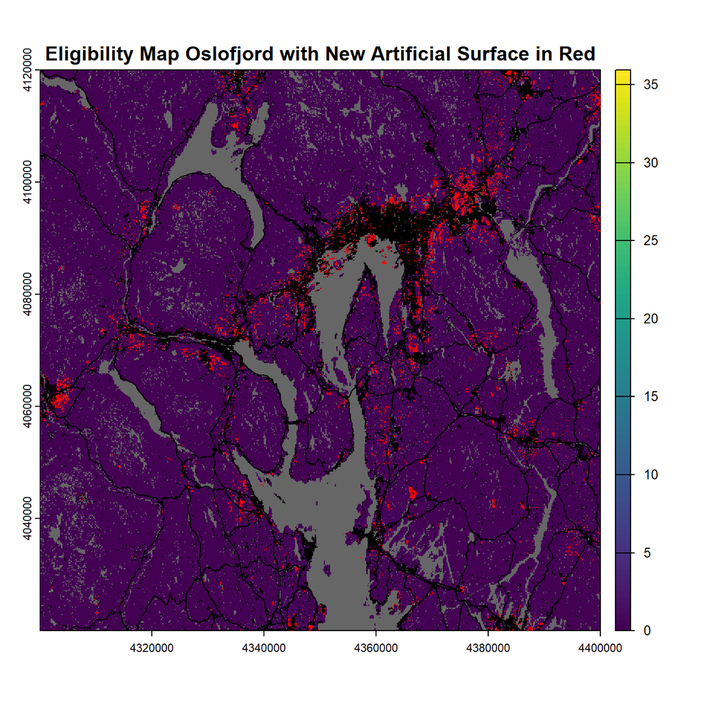

```r
plot(crop(elig_rf,oslo_ext),colNA="grey40",main="Eligibility Map Oslofjord with New Artificial Surface in Red")
plot(crop(urb,oslo_ext),col="black", add=T,legend=F)
plot(crop(newart_r,oslo_ext),col="red", add=T,legend=F)
plot(crop(oslo_r,oslo_ext),add=T)
```

And let’s zoom in on the Hallingdal area.

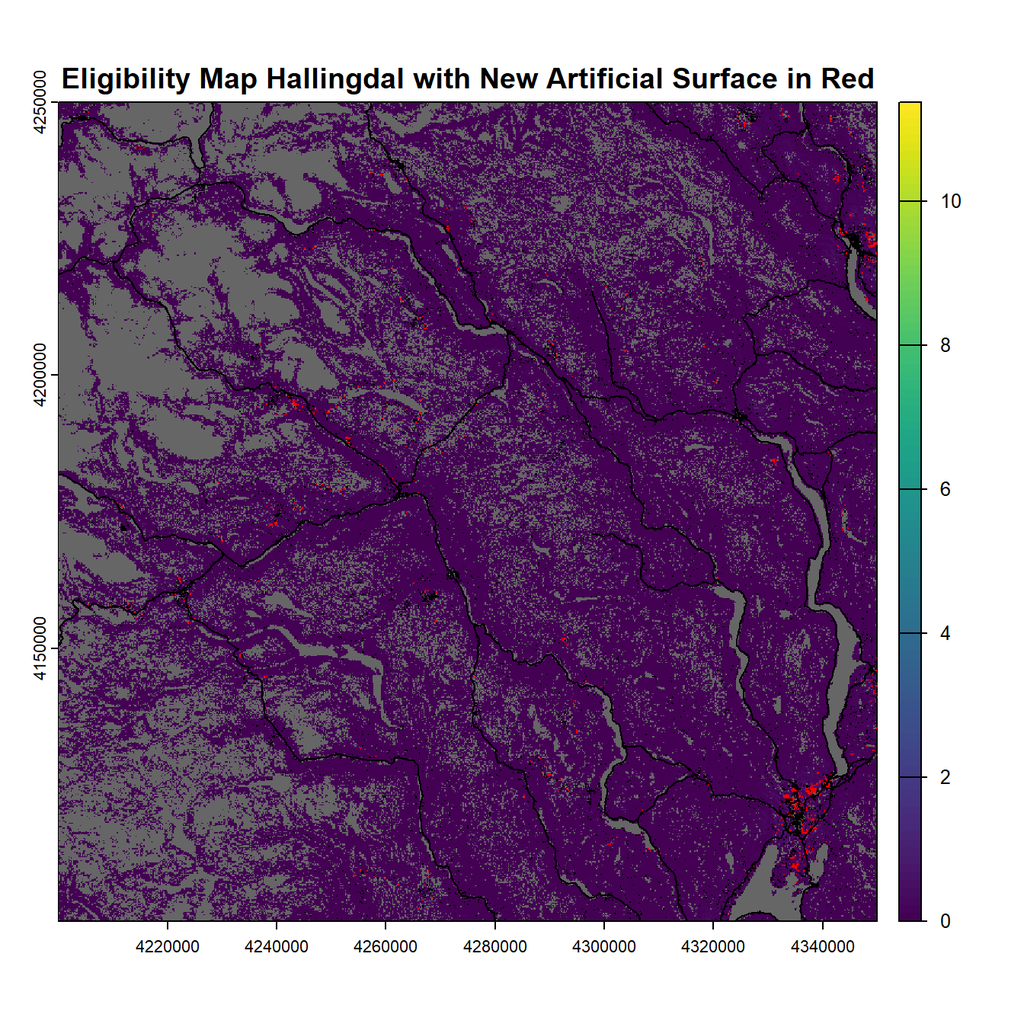

```r
plot(crop(elig_rf,hallingdal_ext),colNA="grey40",main="Eligibility Map Hallingdal with New Artificial Surface in Red")
plot(crop(urb,hallingdal_ext),col="black", add=T,legend=F)
plot(crop(newart_r,hallingdal_ext),col="red", add=T,legend=F)
plot(crop(hallingdal_r,hallingdal_ext),add=T)
```

Zoom in on the Lofoten area.

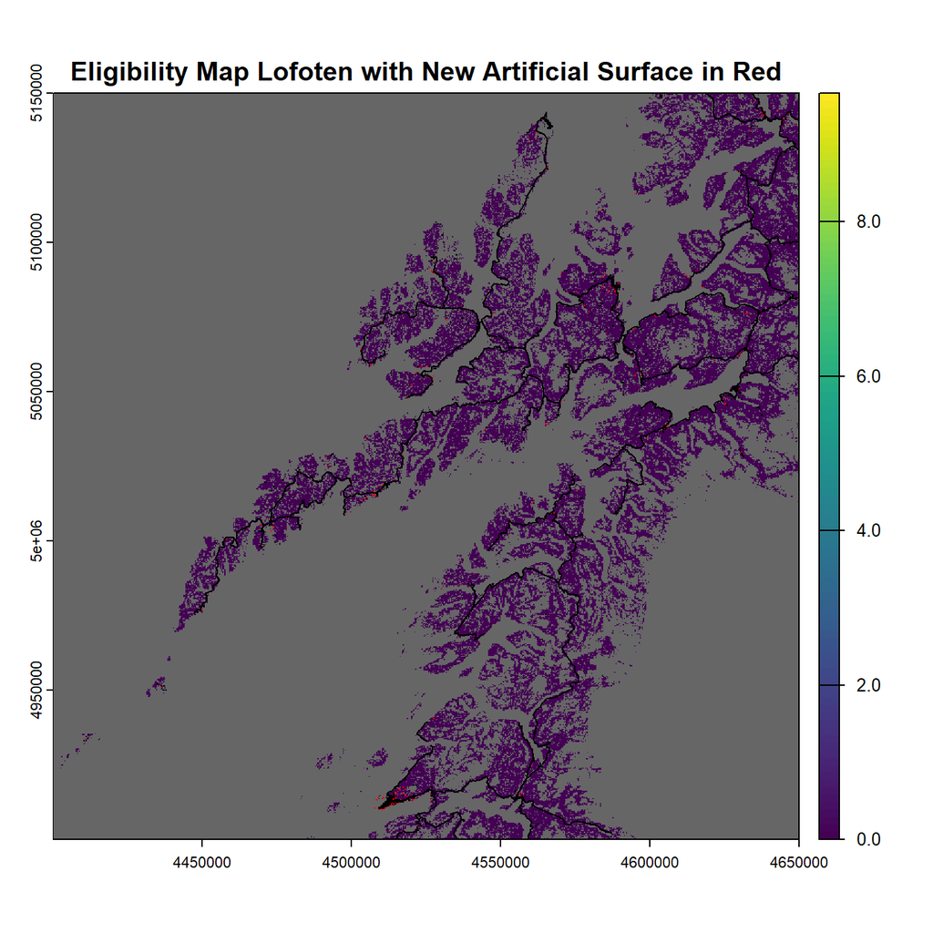

```r
plot(crop(elig_rf,lofoten_ext),colNA="grey40",main="Eligibility Map Lofoten with New Artificial Surface in Red")
plot(crop(urb,lofoten_ext),col="black", add=T,legend=F)
plot(crop(newart_r,lofoten_ext),col="red", add=T,legend=F)
plot(crop(lofoten_r,lofoten_ext),add=T)
```

Zoom in on the Finnmark area.

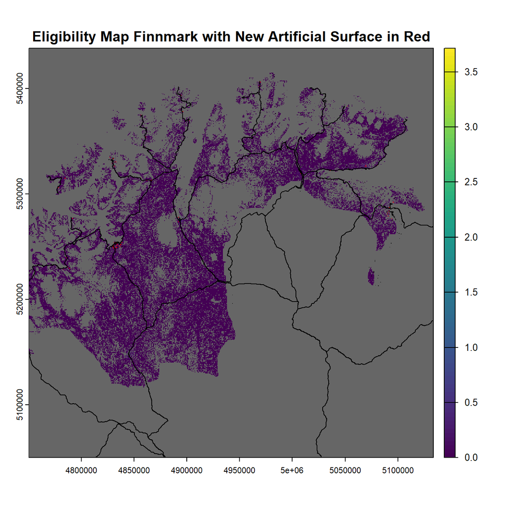

```r
plot(crop(elig_rf,finnmark_ext),colNA="grey40",main="Eligibility Map Finnmark with New Artificial Surface in Red")
plot(crop(urb,finnmark_ext),col="black", add=T,legend=F)
plot(crop(newart_r,finnmark_ext),col="red", add=T,legend=F)
plot(crop(finnmark_r,finnmark_ext),add=T)
```

Here is the allocation rate.

```r
sr<-round(100*((sum(dfd$artif_chg)-sum(values(newart_r),na.rm=T))/sum(dfd$artif_chg)),digits=1)
print(paste0("Predicted artificial surface change was allocated with ",sr," % error margin."))
```

```
## [1] "Predicted artificial surface change was allocated with 0 % error margin."
```

# 7. Result Plots and Tables

To be added, depending on what we want to zoom into. Cities? Specific area cases? Land cover transformation tables? For the time being, we just export some raster maps and calculation tables.

```r
writeRaster(newart_r,file.path(wfp,"results","newartif.tif"),overwrite=T)
writeRaster(round(elig_rf,digits=3),file.path(wfp,"results","eligtif.tif"),overwrite=T)
writeRaster(eligtld_r,file.path(wfp,"results","eligtldtif.tif"),overwrite=T)
write_xlsx(dfd,file.path(wfp,"results","calculationdf.xlsx"))
```